# BIOS 667 - Lecture 1: Introduction to Longitudinal Data (Ch. 1)

Fitzmaurice, Laird & Ware (2011) - Applied Longitudinal Data Analysis

Naim Rashid

## Lecture Objectives

By the end of this lecture, you will be able to:

1. Recognize the **structure** of longitudinal data
2. Distinguish **longitudinal vs. cross-sectional** designs
3. Explain **why correlation matters** for valid inference
4. Describe the **advantages and tradeoffs** of longitudinal designs
5. Identify the **scientific questions** longitudinal studies answer

## Roadmap

1. What is longitudinal data analysis?
2. Why use longitudinal designs?
3. Summary and next steps

## Prerequisites / recall

This lecture assumes you are comfortable with:

- **Intro regression**: fitting a linear model, reading coefficients and standard errors
- **Correlation and covariance**: what they measure and that they are not the same thing

We build on these to motivate why repeated, correlated measurements need special handling.

# Part I: What is Longitudinal Data?

## Definition

> **Longitudinal data**: Repeated measurements collected from the same subjects over time.

**Key goal**: Understand both:

- **Within-person changes** (trajectories)
- **Between-person differences** in those changes

## Example: Six Cities Study (FEV1 Data)

- Tracked annual lung function in children
- This is the **Topeka, Kansas subset (girls)** of the Six Cities Study
- 300 girls, 1-12 repeated measurements per child
- FEV1 = forced expiratory volume; modeled on the **log scale** (`logfev1`)
- Available: `data/fev1.txt`
- FEV1/Six Cities is an instructor-chosen course-wide running example (formally introduced in FLW Ch. 9, Table 9.1), not one of FLW Chapter 1’s four motivating studies (TLC lead trial, Muscatine obesity, anti-epileptic drug trial, Connecticut Child Surveys; FLW Section 1.3)

## Visualizing Repeated Measures

```r
fev <- read.table("../../data/fev1.txt", header = TRUE)

# Sample 15 children for clarity
set.seed(667)
ids <- sample(unique(fev$id), 15)
fev_sub <- fev[fev$id %in% ids, ]

ggplot(fev_sub, aes(x = age, y = logfev1, group = id, color = factor(id))) +
  geom_line(linewidth = 0.8) +
  geom_point(size = 2) +
  theme_minimal() +
  theme(legend.position = "none") +
  labs(title = "Lung Function Trajectories (15 Children)",
       x = "Age (years)", y = "log(FEV1)")
```

## Visualizing Repeated Measures

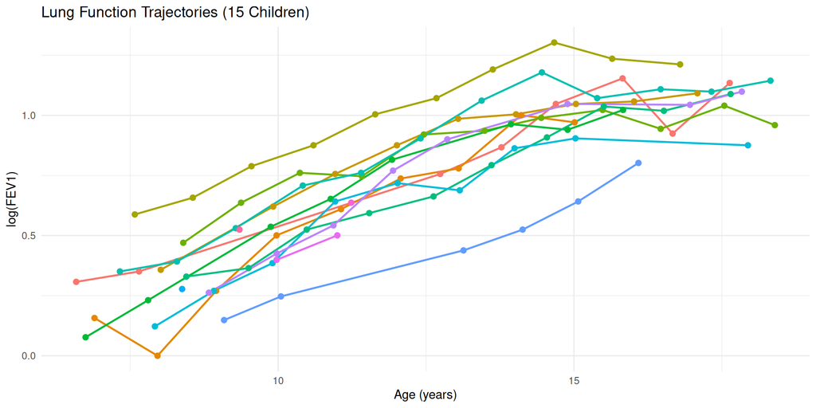

## Key Observation

Each child’s trajectory is **correlated**: measurements don’t bounce randomly.

- Cross-sectional: one dot per child
- Longitudinal: connected trajectory per child

## Cross-Sectional vs. Longitudinal

| Feature | Cross-Sectional | Longitudinal |
| --- | --- | --- |
| Design | One measurement/subject | Repeated measurements |
| Focus | Population snapshot | Trajectories, change |
| Correlation | Independent | Within-subject correlation |
| Efficiency | Less for dynamic questions | Each subject = own control |

**Check Your Understanding: design type**

1. A study measures blood pressure in 500 patients once. Is this longitudinal or cross-sectional data?

**Answer:** Cross-sectional: each patient is measured only once.

**Check Your Understanding: correlation and plots**

2. In the FEV1 study, why are the measurements from the same child correlated?
3. What is the key difference between a spaghetti plot and a scatterplot of all observations?

**Answers:**

2. Measurements from the same child share common characteristics (genetics, environment, baseline lung capacity) that make them more similar to each other than to measurements from other children.
3. A spaghetti plot connects observations within each individual, revealing trajectories; a scatterplot treats all points as independent, hiding the within-person structure.

# Part II: Why Longitudinal Designs?

## Advantages

- **Efficiency**: Each subject serves as their own control
- **Separates aging from cohort effects**: longitudinal designs isolate the within-person change over time from cohort effects that confound cross-sectional comparisons (FLW Section 1.2, body-fat/menarche example)
- **Temporal ordering**: exposure/measurement precedes outcome (a structural feature, not proof of causation)
- **Change rates**: Directly estimate slopes and trajectories
- **Precision**: Baseline adjustment improves power (we return to this in Ch. 5)

## Tradeoffs

- **Dropout**: Missing data patterns (MAR/MNAR)
- **Irregular timing**: Unequal visit schedules
- **Complex dependence**: Requires covariance modeling (Ch. 7-8)

## Why Correlation Matters

Ignoring within-subject correlation leads to:

- **Incorrect standard errors** (the point estimates stay consistent; only the SEs are wrong)
- **Invalid hypothesis tests**
- **Overstated significance**

Proper models must distinguish **within- vs. between-subject effects**.

**Clarification on Standard Errors (FLW pp. 43-44)**

Point estimates ($\hat{\beta}$) remain **consistent** under correct mean specification, even when correlation is ignored. The issue is that standard errors are **inconsistent**: they do not converge to true values. When positive within-subject correlation exists, ignoring it typically **underestimates** standard errors, leading to inflated test statistics and spuriously significant results.

## See It: Naive vs. Cluster SE

The cluster bootstrap here is a pedagogical illustration of the concept. The methods FLW and this course actually use to fix correlation-induced SE problems are correctly specified covariance/mixed models (Ch. 7-8) and the robust sandwich/empirical estimator (GEE, Ch. 13), not the bootstrap.

```r
set.seed(667)

# Simulate clustered data: 50 subjects, 8 visits each,
# strong positive within-subject correlation (shared random intercept).
# The covariate of interest is a BETWEEN-subject (time-invariant) exposure:
# one value per subject, so it is confounded with the cluster structure and
# ignoring within-subject correlation understates its SE.
n_sub <- 50; n_vis <- 8; var_b <- 3   # subject-level variance
sim <- do.call(rbind, lapply(1:n_sub, function(i) {
  b_i <- rnorm(1, 0, sqrt(var_b))      # subject random intercept
  x_i <- rnorm(1)                      # subject-level exposure (one value per subject)
  y   <- 1 + 0.5 * x_i + b_i + rnorm(n_vis)
  data.frame(id = i, x = x_i, y = y)
}))

fit <- lm(y ~ x, data = sim)
naive_se <- summary(fit)$coefficients["x", "Std. Error"]

# Cluster bootstrap: resample whole subjects (keeps within-subject correlation)
boot_b <- replicate(500, {
  ids <- sample(unique(sim$id), replace = TRUE)
  d   <- do.call(rbind, lapply(ids, function(j) sim[sim$id == j, ]))
  coef(lm(y ~ x, data = d))["x"]
})
cluster_se <- sd(boot_b)

se_tab <- data.frame(SE = c("Naive (independence)", "Cluster bootstrap"),
                     value = c(naive_se, cluster_se))

ggplot(se_tab, aes(x = SE, y = value, fill = SE)) +
  geom_col(width = 0.6) +
  geom_text(aes(label = round(value, 3)), vjust = -0.4) +
  theme_minimal() +
  theme(legend.position = "none") +
  labs(title = "Naive SE understates true uncertainty",
       subtitle = "Independence SE is the smaller bar; the cluster bootstrap respects within-subject correlation and is the honest one",
       x = NULL, y = "Standard error of slope")
```

## See It: Naive vs. Cluster SE

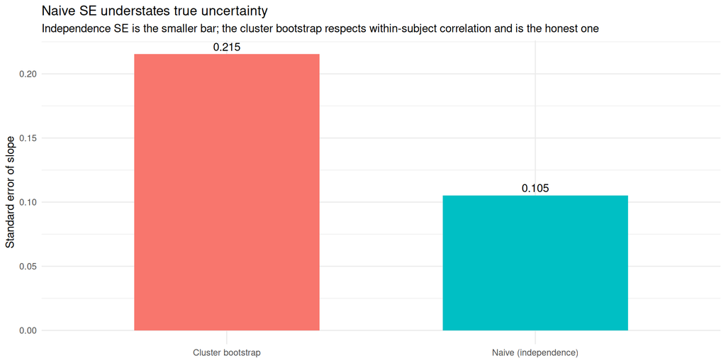

## See It: The Takeaway

For the subject-level exposure `x`, at `set.seed(667)`:

- **Naive (independence) SE:** 0.105
- **Cluster bootstrap SE:** 0.215

The honest cluster SE (0.215) is about 2 times **larger** than the naive SE (0.105).

**Warning**

Ignoring the positive within-subject correlation makes the naive SE too small, so test statistics are inflated and results look more significant than they are. Because the exposure is fixed within a subject, the 8 visits give far less independent information than 400 rows suggest.

## Scientific Questions

Longitudinal analysis addresses:

- **Describe**: Mean trajectories, individual variation
- **Explain**: How covariates shift trajectories
- **Predict**: Future outcomes for individuals/populations
- **Compare**: Treatment effects over time
- **Account for dependence**: Valid inference with correlation

## Longitudinal vs. Clustered Data

| Type | Definition | Example |
| --- | --- | --- |
| Longitudinal | Repeated measures over **time** | FEV1 across visits |
| Clustered | Units within higher-level groups | Students in classrooms |

Techniques overlap, but **time structure** adds constraints and opportunities.

# Summary

## Summary

- **What**: repeated measures on the same subjects over time.
- **Why**: efficient (own control), temporal ordering, direct change rates.
- **Catch**: within-subject correlation corrupts SEs (estimates stay consistent).
- **Use**: describe, explain, predict, and compare trajectories.

## Canonical Resources

- **Author slides**: content.sph.harvard.edu/fitzmaur/ala2e/
- **Datasets**: content.sph.harvard.edu/fitzmaur/ala2e/datasets.html
- **Sample R code**: content.sph.harvard.edu/fitzmaur/ala2e/SampleR.html

## For Next Time

Read **Chapter 2** of Fitzmaurice, Laird & Ware (2011)

- Lecture 2 (Ch. 2): longitudinal data structures, notation, and the sources of within-subject correlation